# Coursework Report

*N* removed NAs: 3

*N* removed typo: 1

*N* removed <18: 22

*N* total clean: 124

| Group | *N* | *M*<sub>age</sub> | *M*<sub>rating</sub> |
| --- | --- | --- | --- |
| Control | 57 | 21.16 | 6.43 |
| Experim | 67 | 21.22 | 5.77 |

**Main analysis results**

*t*(122) = 4.76, *p* < .001

[interactive chart not shown]

[figure not shown]

[interactive chart not shown]

# Coursework Report

Analysing Data, Spring 2020

# Methods

## Design

This study is interested in determining whether the colour red will influence perceived male attractiveness as rated by by females in a close replication on Elliot et al., 2010.

A black and white photograph of the head and upper torso of a moderately attaractive, young, Caucasian man was shown for 5 seconds. The 4-in by 6-in photograph was taken from a standard photo set and centred on a 8.5-in by 11-in page creating a frame around the photograph. The independent variable that was manipulated was the colour of this frame. This factor had two levels: white in the control condition and red in the experimental condition. The dependent variable was attractiveness and was measured as the mean rating of attractiveness given by women on 3 subscales. These 3 9-point subscales asked “How attractive do you think this person is?”, “How pleasant is this person to look at?” and “If I were to meet the person in this picture face to face, I would think he is attractive.”. A rating of 1 meant not attractive at all, and 9 meant extremely attractive. A composite score was generated by averaging the 3 ratings on the subscales to create a mean attractiveness rating.

Previous research by Elliot et al., 2010 suggests that the colour red will incresase ratings of attractiveness, the present research specically aims to identify any sinificant difference in mean attractiveness ratings of a photograph of a man between 2 conditions; white and red framed. This difference will be statistically tested using an independent-samples *t* test with a *p*<.05 being considered significant.

# Results

The general pattern of results indicate that in the experimental condition the rating of attractiveness was lower than in the control condition, contradicting our research hypothesis.

Table of average attractiveness score by condition

| Condition | Mean | SD |
| --- | --- | --- |
| control | 6.43 | 0.87 |
| experimental | 5.77 | 0.67 |

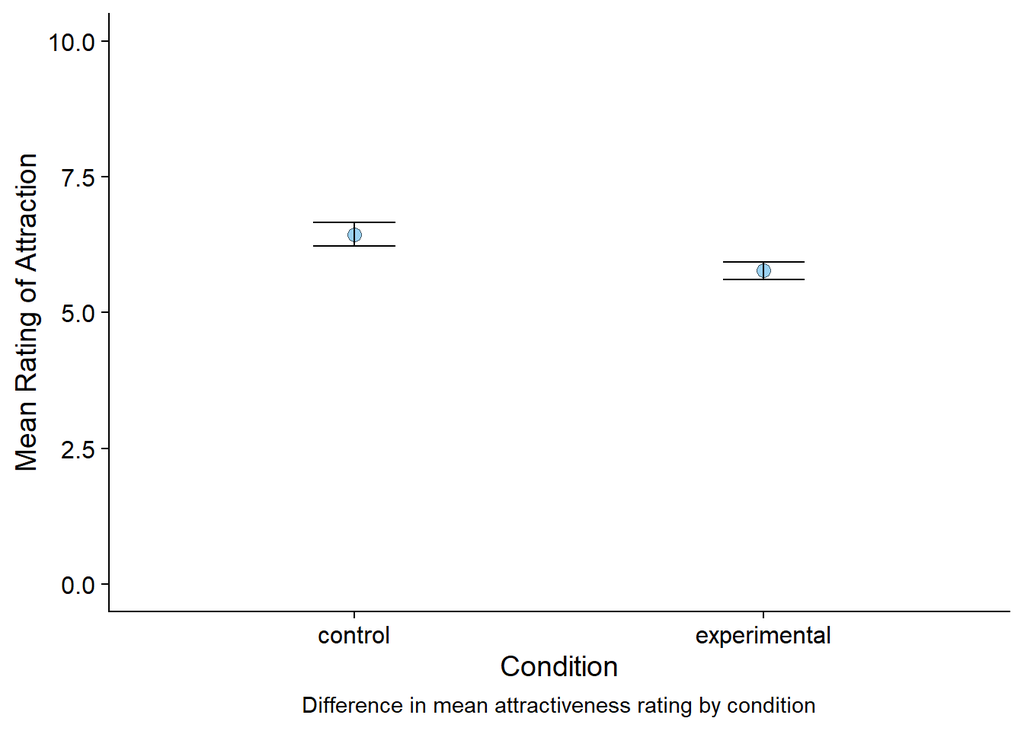

Using an independent-measures *t* test the effect of colour on mean attractiveness rating was scrutinised. This test showed that the means in the two conditions were significantly different: (*M*<sub>diff</sub> = 0.66, 95% CI [0.39, 0.94]), *t* (122) = 4.76, *p* < .05.

# Discussion

The data from the present study reflects a significant relationship between colour and attractiveness, however in the opposite direction to that which was predicted. Males on a white background were rated as significantly more attractive than on a red background. These findings directly contradict findings from Elliot et al., 2010 despite being a close replication, questioning not only the theory behind the assumption that red increases perception of attractiveness, but also their original study. Findings from Elliot et al., 2010 have large effect sizes and have often been cited as significant support of red’s effect on attraction. However, the validity of these conclusions is questionable and may hold some bias. Considering the power value of their experiments one would expect at least some of their 12 experiments to fail to reject the null hypothesis, however all of their results supported the alternative hypothesis, the probability of this happening is 0.005 (Francis, 2013). This test of bias may have been used without the correct amount of caution and arguably an invalid application (Elliot & Maier, 2013). Nonetheless, the statistical questionability does bring a level of scrutiny to this popular study, highlighting its apparent lack of replicability. Beyond the present study and Elliot et al., 2010, data on the influence of red on attraction is highly inconsistent. There is a significant amount of research similar to the present research which fails to support the claim that red increases perception of attractiveness. Elliot & Maier, 2013, in contradiction to their earlier findings, were unable to find a significant difference between red and grey conditions with a larger sample size. A number of other studies, including the present study, have also failed to turn out support for a colour effect on attraction suggesting the effect may be extremely weak or non-existent (Hesslinger et al., 2015; Lynn et al., 2016; Peperkoorn et al., 2016)

It is useful to consider why the link between red and attractiveness was theorised initially to examine why results do not consistently support it. Colour in context theory was proposed by Elliot and Maier to “explain and predict relations between color and affect, cognition, and behavior” (Elliot & Maier, 2012). They suggest colour has meaning and effects psychological functioning automatically in relation to context. One application of this theory lies in affiliation, specifically that the colour red facilitates heterosexual attraction. Culturally, the colour red is often associated with ideas such as love, sex, strength, and power (Elliot & Maier, 2012). Moreover, it appears to be universal even across species, for example red is perceived as attractive in finches (Burley et al., 1994) and rhesus macaques (Dubuc et al., 2014). Furthermore, many female vertebrates display red on their body when nearing ovulation, arguably to signal sexual receptivity, this may be far less obvious in humans but may still be apparent in sexual and flirtatious flushes near (Elliot & Maier, 2012). Similarly, in males red is considered attractive in non-human and human vertebrates alike. In humans high male testosterone levels are generally indicative of health and strength (Blas et al., 2006) and often manifests as higher social status (Mazur & Booth, 1998). High testosterone is linked to increase in blood flow to visible areas of the skin, increasing redness (Elliot & Maier, 2012). Similarly, red skin is associated with physiological health since high vascular performance results in more oxygenated (redder) blood. This association between colour and perceived attractiveness may extend beyond biological signals to artificial ones, such as ornamentation of red items (Elliot & Maier, 2012). Colour in context theory relies heavily on non-human examples and assumptions. It is a highly reductionist approach, failing to acknowledge the vast number of other factors that influence attraction. Hesslinger et al., 2015 for example, demonstrate the importance of apparel style in contrast to colour effects in determining attraction. Furthermore, although the colour red may have tenuous links to status through physical health and fitness there are many other, more obvious and arguably more valid indicators of status can be found through socioeconomic markers. Moreover, status is highly context dependent and socially constructed in many ways, making it irreducible to a simple biological mechanism. Physical prowess and health in males may have been a significant factor in attraction when there were physical threats and it was necessary to hunt and gather food, but in modern societies a high-status man is often determined by his socio-economic success, not necessarily his physical strengths. These limitations of colour in context theory offer an explanation for why the present findings and a wealth of other contradicting evidence fails to support the link between red and attraction.

Regarding the present research, it is important to consider its limitations before attempting to explain the observed effect. Firstly, the present experiment had a limited sample. Using undergraduate students provides an easy to acquire sample but are of a limited age and demographic so will not accurately reflect the general population. Secondly, there was only one photograph of a single moderately attractive male. This limits the ecological validity of the study since it does not closely reflect the variability of physical appearance found in reality (Hesslinger et al., 2015). Thirdly, the narrow focus on colour effects limits the findings of the research. The high control of variables in a laboratory setting allows the internal validity to be extremely high and we can be sufficiently sure that we are measuring the effects of colour on attractiveness. However, it leads to failure to acknowledge the complex range of influences acting upon people in real world interactions. Colour may even act in more complex ways than depicted in this study. Colour has been found to influence attractiveness of the wearer even when the colour was obscured, suggesting the colour has a psychological influence on the wearer which ultimately influences perceived attractiveness (Roberts et al., 2010). With these limitations in mind, the effects found in the present study could be explained in the context of long-term and short-term mate preferences. In western cultures white can be considered pure and a sign of premarital chastity, especially in women, which is important given the issue of paternal uncertainty and it would likely be displayed by females to attract mates (Peperkoorn et al., 2016). Similarly, it could be postulated that white also symbolises chastity in men and suggests willingness to commit to a monogamous relationship and therefore full investment in one family. While signals of red might be used as an indicator of possible interest in more casual, short-term relationships, white may indicate traits desirable in long-term relationships (Peperkoorn et al., 2016). It could be theorised that in the present study males were more likely to be pursuing long-term mating strategies. This could be because of the sample that was used or perhaps because the questions used were leading.

In summary, the present research fails to replicate results from Elliot et al., 2010. It adds to a wealth of evidence that empirically challenges the assumption that red increases perception of attractiveness. Moreover, findings suggest a stronger connection between white and attractiveness, an area with little investigation. From this study a need for larger size investigations into the effect of colour on attraction with rigorous testing has been highlighted, specifically how red and white may influence attraction in different mating strategies.

# References

Blas, J., Pérez-Rodríguez, L., Bortolotti, G. R., Viñuela, J., & Marchant, T. A. (2006). Testosterone increases bioavailability of carotenoids: Insights into the honesty of sexual signaling. *Proceedings of the National Academy of Sciences, 103*(49), 18633–18637.

Burley, N. T., Enstrom, D. A., & Chitwood, L. (1994). Extra-pair relations in zebra finches: Differential male success results from female tactics. *Animal Behaviour, 48*(5), 1031–1041.

Dubuc, C., Allen, W. L., Maestripieri, D., & Higham, J. P. (2014). Is male rhesus macaque red color ornamentation attractive to females? *Behavioral Ecology and Sociobiology, 68*(7), 1215–1224.

Elliot, A. J., & Maier, M. A. (2012). Chapter two—Color-in-Context Theory. P. Devine & A. Plant (Eds.), *Advances in Experimental Social Psychology* (Vol. 45, pp. 61–125). Academic Press.

Elliot, A. J., & Maier, M. A. (2013). The red-attractiveness effect, applying the Ioannidis and Trikalinos (2007b) test, and the broader scientific context: A reply to Francis (2013). *Journal of Experimental Psychology: General, 142*(1), 297–300.

Elliot, A. J., Niesta Kayser, D., Greitemeyer, T., Lichtenfeld, S., Gramzow, R. H., Maier, M. A., & Liu, H. (2010). Red, rank, and romance in women viewing men. *Journal of Experimental Psychology: General, 139*(3), 399–417.

Hesslinger, V. M., Goldbach, L., & Carbon, C.-C. (2015). Men in red: A reexamination of the red-attractiveness effect. *Psychonomic Bulletin & Review, 22*(4), 1142–1148.

Lynn, M., Giebelhausen, M., Garcia, S., Li, Y., & Patumanon, I. (2016). Clothing Color and Tipping: An Attempted Replication and Extension. *Journal of Hospitality & Tourism Research, 40*(4), 516–524.

Mazur, A., & Booth, A. (1998). Testosterone and dominance in men. *Behavioral and Brain Sciences, 21*(3), 353–363.

Peperkoorn, L. S., Roberts, S. C., & Pollet, T. V. (2016). Revisiting the Red Effect on Attractiveness and Sexual Receptivity: No Effect of the Color Red on Human Mate Preferences. *Evolutionary Psychology, 14*(4), 1474704916673841.

Roberts, S. C., Owen, R. C., & Havlicek, J. (2010). Distinguishing between Perceiver and Wearer Effects in Clothing Color-Associated Attributions. *Evolutionary Psychology, 8*(3), 147470491000800320.